# Introducing bigDM package

A. Adin, E. Orozco-Acosta, M.D. Ugarte

2020-07-21

## Introduction

**bigDM** is a package that implements several (scalable) spatial Poisson mixed models for high-dimensional areal count data, with inference in a fully Bayesian setting using the integrated nested Laplace approximation (INLA) technique (Rue et al., 2009). This vignette focuses on how to use the **bigDM** package to fit the scalable model’s proposals described in (Orozco-Acosta et al., 2020) using Spanish colorectal cancer mortality data.

The development version is hosted on [GitHub](https://github.com/spatialstatisticsupna/bigDM) and can be installed as follows:

```r
# Install devtools package from CRAN repository
install.packages("devtools")

# Load devtools library
library(devtools)

# Install the R-INLA package
install.packages("INLA", repos=c(getOption("repos"), INLA="https://inla.r-inla-download.org/R/stable"), dep=TRUE)

# Install bigDM from GitHub repositoy
install_github("spatialstatisticsupna/bigDM")
```

## Spatial models in disease mapping

Let us assume that the spatial domain of interest is divided into $n$ contiguous small areas labeled as $i=1,\ldots,n$. For a given area $i$, let $O_i$ and $E_i$ denote the observed and expected number of disease cases, respectively. Using these quantities, the (SMR or SIR) is defined as the ratio of observed and expected cases for the corresponding areal unit. Although its interpretation is very simple, these measures are extremely variable when analyzing rare diseases or low-populated areas, as it is the case of high-dimensional data. To cope with this situation, it is necessary to use statistical models that stabilize the risks (rates) borrowing information from neighbouring regions.

Poisson mixed models are typically used for the analysis of count data within a hierarchical Bayesian framework. Conditional to the relative risk $r_i$, the number of observed cases in the $i$th area is assumed to be Poisson distributed with mean $\mu_{i}=E_{i}r_{i}$.

That is,
$$\begin{eqnarray*}
\label{eq:Model_Poisson}
\begin{array}{rcl}
O_{i}|r_{i} & \sim & Poisson(\mu_{i}=E_{i}r_{i}), \ i=1,\ldots,n\\
\log \mu_{i} & = & \log E_{i}+\log r_{i},
\end{array}
\end{eqnarray*}$$
where $\log E_{i}$ is an offset. Depending on the specification of the log-risks different models are defined.

Here we assume that
$$\begin{equation}
\log r_{i}=\alpha+\xi_{i},
\tag{1}
\end{equation}$$
where $\alpha$ is an intercept representing the overall log-risk and $\boldsymbol{\xi}=(\xi_1,\ldots,\xi_n)^{'}$ is a spatial random effect for which a conditional autoregressive (CAR) prior is usually assumed. The spatial correlation between CAR random effects is determined by the neighbouring structure (represented as an undirected graph) of the areal units. Let $\textbf{W}=(w_{ij})$ be a binary $n \times n$ adjacency matrix, whose $ij$th element is equal to one if areas $j$ and $k$ are defined as neighbours (usually if they share a common border), and it is zero otherwise.

### Prior distributions

The following prior distributions are implemented in the `CAR_INLA()` function for the spatial random effect (specified throught the `prior=...` argument):

- **intrinsic CAR prior (iCAR)**

  The joint distribution of the iCAR prior (Besag et al., 1991) is defined as
  $$\begin{equation*}
  \label{eq:iCAR}
  \boldsymbol{\xi} \sim N(\textbf{0},\textbf{Q}^{-}_{\xi}), \quad \mbox{with} \quad \textbf{Q}_{\xi}=\tau_{\xi}(\textbf{D}_{W}-\textbf{W})
  \end{equation*}$$
  where $\textbf{D}_{W} = diag(w_{1+},\ldots,w_{n+})$ and $w_{i+}=\sum_j w_{ij}$ is the $i$th row sum of $\textbf{W}$, and $\tau_{\xi}=1/\sigma^2_{\xi}$ is the precision parameter. As $\textbf{Q}_{\xi}\textbf{1}_n=\textbf{0}$, where $\textbf{1}_n$ is a vector of ones of length $n$ (i.e., $\textbf{1}_n$ is the eigenvector associated to the null eigenvalue of $\textbf{Q}_{\xi}$), the precision matrix of the iCAR distribution is singular and therefore, the joint distribution of $\boldsymbol{\xi}$ is improper. If the spatial graph is fully connected (matrix $\textbf{Q}_{\xi}$ has rank-deficiency equal to 1), a sum-to-zero constraint $\sum_{i=1}^n \xi_i = 0$ is usually imposed to solve the identifiability issue between the spatial random effect and the intercept.
- **BYM prior**

  A convolution CAR prior (usually named as BYM prior) was also proposed by Besag et al. (1991) and combines the iCAR prior and an additional set of unstructured random effects. The model is given by
  $$\begin{equation*}
  \label{eq:BYM}
  \boldsymbol{\xi} = \textbf{u} + \textbf{v}, \quad \mbox{with} \quad \begin{array}{l} \textbf{u} \sim N(\textbf{0},[\tau_{u}(\textbf{D}_{W}-\textbf{W})]^{-}), \\ \textbf{v} \sim N(\textbf{0},\tau_{v}^{-1}\textbf{I}_n). \end{array}
  \end{equation*}$$
  where $\textbf{I}_n$ is the $n \times n$ identity matrix. The precision parameters of the spatially structured random effect ($\tau_{u}$) and the unstructured random effect ($\tau_{v}$) are not identifiable from the data , just the sum $\xi_i=u_i + v_i$ is identifiable. Hence, similar to the iCAR prior distribution, the sum-to-zero constraint $\sum_{i=1}^n (u_i+v_i) = 0$ must be imposed to solve identifiability problems with the intercept.
- **LCAR prior**

  Leroux et al. (1999) propose an alternative CAR prior (named as LCAR prior) to model both spatially structured and unstructured variation in a single set of random effects. It is given by
  $$\begin{equation*}
  \label{eq:LCAR}
  \boldsymbol{\xi} \sim N(\textbf{0},\textbf{Q}^{-1}_{\xi}), \quad \mbox{with} \quad \textbf{Q}_{\xi}=\tau_{\xi}[\lambda_{\xi}(\textbf{D}_W-{\textbf{W}})+(1-\lambda_{\xi})\textbf{I}_n]
  \end{equation*}$$
  where $\tau_{\xi}$ is the precision parameter and $\lambda_{\xi} \in [0,1]$ is a spatial smoothing parameter. Even the precision matrix $\textbf{Q}_{\xi}$ is of full rank whenever $0 \leq \lambda_{\xi} < 1$, a confounding problem still remains and consequently, a sum-to-zero constraint $\sum_{i=1}^n \xi_i = 0$ has to be considered (see Goicoa et al. (2018)).
- **BYM2 prior**

  In Riebler et al. (2016) a modification of the Dean et al. (2001) model was proposed which addresses both the identifiability and scaling issue of the BYM model, hereafter BYM2 model. Here, the spatial random effect is reparameterized as
  $$\begin{equation}
  \label{eq:BYM2}
  \boldsymbol{\xi} = \frac{1}{\sqrt{\tau_{\xi}}}(\sqrt{\lambda_{\xi}}\textbf{u}_{\star} + \sqrt{1-\lambda_{\xi}}\textbf{v}),
  \end{equation}$$
  where $\textbf{u}_{\star}$ is the scaled intrinsic CAR model with generalized variance equal to one and $\textbf{v}$ is the vector of unstructured random effects. The variance of is expressed as a weighted average of the covariance matrices of the structured and unstructured spatial components (unlike the LCAR model which considers a weighted combination of the precision matrices), i.e.,
  $$\begin{equation*}
  \mbox{Var}(\boldsymbol{\xi}|\tau_{\xi})=\frac{1}{\tau_{\xi}}(\lambda_{\xi}\textbf{R}_{\star}^{-} + (1-\lambda_{\xi})\textbf{I}_n),
  \end{equation*}$$
  where $\textbf{R}_{\star}^{-}$ indicates the generalised inverse of the scaled spatial precision matrix (Sørbye & Rue, 2014). As in the previous models, a sum-to-zero constraint $\sum_{i=1}^n \xi_i =0$ must be imposed to avoid identifiability problems.

By default (`PCpriors=FALSE` argument), improper uniform prior distributions on the positive real line are considered for the standard deviations, i.e., $\sigma_{\xi} = 1/\sqrt{\tau_{\xi}} \sim U(0,\infty)$. In addition, a standard uniform distribution is given to the spatial smoothing parameter $\lambda_{\xi}$ when fitting the LCAR or BYM2 model for the spatial random effect. See Ugarte et al. (2016) for details about how to implement these hyperprior distributions in R-INLA.

If setting `PCpriors=TRUE` argument, then penalised complexity (PC) priors (Simpson et al., 2017) are used for the precision parameter of the spatial random effect $\boldsymbol{\xi}$. This option only works if iCAR (`prior="intrinsic"` argument) or BYM2 (`prior="BYM2"` argument) spatial prior distributions are selected. In both cases, the default values in R-INLA $(U,\alpha)=(1,0.1)$ are considered for the standard deviation of the random effect, which means that $P(\sigma_{\xi}>1)=0.1$. If the BYM2 model is selected, the values $(U,\alpha)=(0.5,0.5)$ are also given to the spatial smoothing parameter $\lambda_{\xi}$, that is, $P(\lambda_{\xi}>0.5)=0.5$.

### INLA approximation strategy

The following approximation strategies are implemented in R-INLA: Gaussian (`strategy="gaussian"`), simplified Laplace (`strategy="simplifed.laplace"`) or full Laplace (`strategy="laplace"`). The Gaussian approximation is the fastest option and often gives reasonable results, but it may be inaccurate. The full Laplace approximation is very accurate, but it can be computationally expensive. The simplified Laplace approximation (default option in `CAR_INLA()` function) offers a tradeoff between accuracy and computing time. See Rue et al. (2009) for details about the approximation strategies in INLA.

## Initial step: input argument for the `CAR_INLA` function

The input argument of the `CAR_INLA()` function must be an object of class `sf` or `SpatialPolygonsDataFrame` which contains the data of analysis and its associated cartography file. Note that **bigDM** includes the `Carto_SpainMUN` sf (simple feature) object containing the polygons of Spanish municipalities and simulated colorectal cancer mortality data (modified in order to preserve the confidentiality of the original data).

```r
library(bigDM)

head(Carto_SpainMUN)
```

```
#> Simple feature collection with 6 features and 9 fields
#> geometry type:  MULTIPOLYGON
#> dimension:      XY
#> bbox:           xmin: 485318 ymin: 4727428 xmax: 543317 ymax: 4779153
#> CRS:            +proj=utm +zone=30 +ellps=GRS80 +units=m +no_defs
#>      ID                                    name     lat    long     area
#> 1 01001                        Alegria-Dulantzi 4742974 4742974 19913794
#> 2 01002                                 Amurrio 4765886 4765886 96145595
#> 3 01003                                 Aramaio 4766225 4766225 73338806
#> 4 01004                              Artziniega 4775453 4775453 27506468
#> 5 01006                                 Arminon 4729884 4729884 10559721
#> 6 01008 Arrazua-Ubarrundia (San Martin de Ania) 4752714 4752714 57502811
#>   perimeter obs        exp     region                       geometry
#> 1  34372.11   4  3.0237149 Pais Vasco MULTIPOLYGON (((538259 4737...
#> 2  63352.32  27 20.8456682 Pais Vasco MULTIPOLYGON (((503520 4760...
#> 3  41430.46   6  3.7527301 Pais Vasco MULTIPOLYGON (((533286 4759...
#> 4  22605.22   5  3.2093191 Pais Vasco MULTIPOLYGON (((491260 4776...
#> 5  17847.35   0  0.4817391 Pais Vasco MULTIPOLYGON (((509851 4727...
#> 6  64968.81   1  1.9643891 Pais Vasco MULTIPOLYGON (((534678 4746...
```

In what follows, we describe how to create this object in `R` from a cartography shapefile (.shp) format and data file (.csv) containing the data of analysis:

1. Read the shapefile of Spanish municipalities as an object of class `SpatialPolygonsDataFrame`

```r
library(rgdal)

carto_spdf <- readOGR(system.file("shape/Carto_SpainMUN.shp", package="bigDM"))
```

or alternatively, as an object of class `sf`

```r
library(sf)

carto_sf <- st_read(system.file("shape/Carto_SpainMUN.shp", package="bigDM"))
```

2. Read the csv file with the simulated colorectal cancer mortality data and merge with the cartography file. Note that both files must contain a common identifier variable for the areas (polygons).

```r
library(readr)

data <- read_csv(system.file("csv/data.csv", package="bigDM"))
carto <- merge(carto_sf, data, by="ID")

head(carto)
```

```
#> Simple feature collection with 6 features and 11 fields
#> geometry type:  MULTIPOLYGON
#> dimension:      XY
#> bbox:           xmin: 485318 ymin: 4727428 xmax: 543317 ymax: 4779153
#> CRS:            unknown
#>      ID                                    name     lat    long     area
#> 1 01001                        Alegria-Dulantzi 4742974 4742974 19913794
#> 2 01002                                 Amurrio 4765886 4765886 96145595
#> 3 01003                                 Aramaio 4766225 4766225 73338806
#> 4 01004                              Artziniega 4775453 4775453 27506468
#> 5 01006                                 Arminon 4729884 4729884 10559721
#> 6 01008 Arrazua-Ubarrundia (San Martin de Ania) 4752714 4752714 57502811
#>   perimeter obs.x      exp.x     region obs.y      exp.y
#> 1  34372.11     4  3.0237149 Pais Vasco     4  3.0237149
#> 2  63352.32    27 20.8456682 Pais Vasco    27 20.8456682
#> 3  41430.46     6  3.7527301 Pais Vasco     6  3.7527301
#> 4  22605.22     5  3.2093191 Pais Vasco     5  3.2093191
#> 5  17847.35     0  0.4817391 Pais Vasco     0  0.4817391
#> 6  64968.81     1  1.9643891 Pais Vasco     1  1.9643891
#>                         geometry
#> 1 MULTIPOLYGON (((538259 4737...
#> 2 MULTIPOLYGON (((503520 4760...
#> 3 MULTIPOLYGON (((533286 4759...
#> 4 MULTIPOLYGON (((491260 4776...
#> 5 MULTIPOLYGON (((509851 4727...
#> 6 MULTIPOLYGON (((534678 4746...
```

## Global model

We denote as *Global model* to the spatial model described in Equation (1), where the whole neighbourhood graph of the areal units is considered to define the adjacency matrix $\textbf{W}$.

The *Global model* is fitted using the `CAR_INLA()` function as

```r
## Not run:
Global <- CAR_INLA(carto=Carto_SpainMUN, ID.area="ID", O="obs", E="exp", model="global")
```

where `ID` is a character vector of geographic identifiers of the Spanish municipalities, while `obs` and `exp` are the variables with the observed and expected number of colorrectal cancer mortality cases in each municipality, respectively.

By default, the LCAR prior distribution is considered for the spatial random effect $\boldsymbol{\xi}$, and the simplified Laplace approximation strategy is used to fit the model (arguments `prior="Leroux"` and `strategy="simplified.laplace`, respectively).

## Disjoint model

The key idea of the *Disjoint model* is to define a partition of the whole spatial domain $\mathscr{D}$ into $D$ subregions, that is $\mathscr{D} = \bigcup_{d=1}^D \mathscr{D}_d$ where $\mathscr{D}_i \cap \mathscr{D}_j = \emptyset$ for all $i \neq j$. In our disease mapping context, this means that each geographical unit belongs to a single subregion. A natural choice for this partition could be the administrative subdivisions of the area of interest (such as for example, provinces or states). For our example data in `Carto_SpainMUN` the $D=15$ Autonomous Regions of Spain are used as a partition of the $n=7907$ municipalites (`region` variable of the `sf` object).

If the user has no idea on how to define this initial partition, the `random_partition()` function can be used to define a regular grid over the associated cartography with a certain number of rows and columns. For example, let us define a random partition for the Spanish municipalities based on a 3x3 regular grid

```r
carto.new <- random_partition(carto=Carto_SpainMUN, rows=3, columns=3)
```

The result is an object of class `sf` with the original data and a grouping variable named `ID.group`. We can use this variable to plot the spatial partition using the **tmap** library as

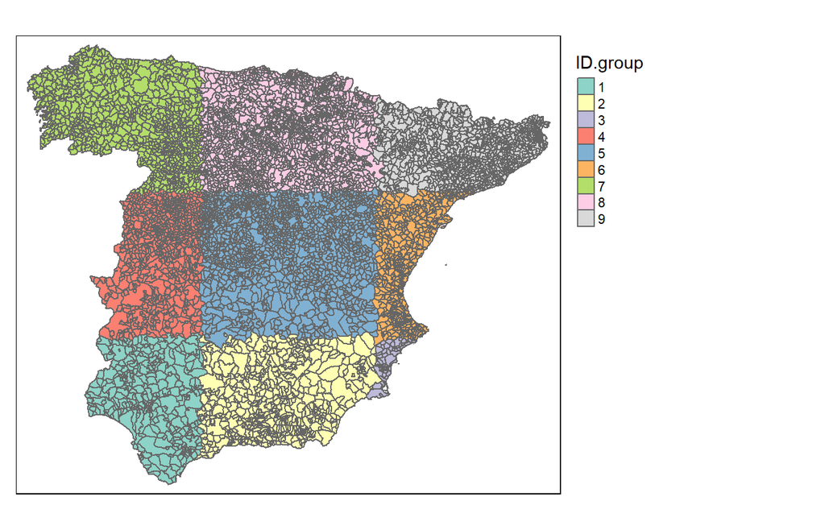

Figure 1: Random partition for the Spanish municipalities based on a 3x3 regular grid.

```r
library(tmap)

tm_shape(carto.new) +
  tm_polygons(col="ID.group") +
  tm_layout(legend.outside=TRUE)
```

Once the partition variable is defined, the *Disjoint model* is fitted using the `CAR_INLA()` function as

```r
Disjoint <- CAR_INLA(carto=Carto_SpainMUN, ID.area="ID", ID.group="region", O="obs", E="exp",
                     model="partition", k=0, seed=1234, strategy="gaussian", save.models=TRUE)
```

```
#> STEP 1: Pre-processing data
#> STEP 2: Fitting partition (k=0) model with INLA
#> + Model 1 of 15
#> + Model 2 of 15
#> + Model 3 of 15
#> + Model 4 of 15
#> + Model 5 of 15
#> + Model 6 of 15
#> + Model 7 of 15
#> + Model 8 of 15
#> + Model 9 of 15
#> + Model 10 of 15
#> + Model 11 of 15
#> + Model 12 of 15
#> + Model 13 of 15
#> + Model 14 of 15
#> + Model 15 of 15
#> + Saving all the inla submodels in '/temp/' folder
#> STEP 3: Merging the results
```

```r
summary(Disjoint)
```

```
#>
#> Call:
#>    c("inla(formula = formula, family = \"poisson\", data = data.INLA[[i]],
#>    ", " E = E, control.compute = list(dic = TRUE, cpo = TRUE, waic = TRUE,
#>    ", " config = TRUE), control.predictor = list(compute = TRUE, ", " cdf
#>    = c(log(1))), control.inla = list(strategy = strategy))" )
#> Time used:
#>     Pre = 4.08, Running = 84.4, Post = 5.71, Merging = 29.1
#> Random effects:
#>   Name     Model
#>     ID.area Generic1 model
#>
#> Deviance Information Criterion (DIC) ...............: 28205.55
#> Deviance Information Criterion (DIC, saturated) ....: 8362.02
#> Effective number of parameters .....................: 297.88
#>
#> Watanabe-Akaike information criterion (WAIC) ...: 28181.89
#> Effective number of parameters .................: 251.19
#>
#> Posterior marginals for the linear predictor and
#>  the fitted values are computed
```

The result is an object of class `inla` where the relative risks $r_i$ are just the union of the posterior marginal estimates of each submodel. If the `save.models=TRUE` argument is included, a list with all the inla submodels is saved in temporary folder, which can be used as input argument for the `mergeINLA()` function. In addition, the `compute.fixed=TRUE` argument can be included to compute the overall log-risk $\alpha$ by generating samples from the joint posterior distribution of the linear predictors. Further details are given below.

## k-order neighbourhood models

To avoid border effects in the disease mapping estimates when fitting the *Disjoint model*, we also propose a second modeling approach where $k$-order neighbours are added to each subregion of the spatial domain. Doing so, $\mathscr{D}$ is now divided into overlapping set of regions, that is, $\mathscr{D} = \bigcup_{d=1}^D \mathscr{D}_d$ but $\mathscr{D}_i \cap \mathscr{D}_j \neq \emptyset$ for neighbouring subregions. This implies that, for some areal units, multiple risk estimates will be obtained. To obtain a unique posterior distribution of $r_i$ for each areal unit $i$, we propose to compute a mixture distribution using the estimated posterior probability density function of these risks. Further details are given below.

The *k-order neighbourhood model* is fitted using the `CAR_INLA()` function as

```r
## 1st order neighbourhood model ##
order1 <- CAR_INLA(carto=Carto_SpainMUN, ID.area="ID", ID.group="region", O="obs", E="exp",
                   model="partition", k=1, seed=1234, strategy="gaussian", save.models=TRUE)
```

```
#> STEP 1: Pre-processing data
#> STEP 2: Fitting partition (k=1) model with INLA
#> + Model 1 of 15
#> + Model 2 of 15
#> + Model 3 of 15
#> + Model 4 of 15
#> + Model 5 of 15
#> + Model 6 of 15
#> + Model 7 of 15
#> + Model 8 of 15
#> + Model 9 of 15
#> + Model 10 of 15
#> + Model 11 of 15
#> + Model 12 of 15
#> + Model 13 of 15
#> + Model 14 of 15
#> + Model 15 of 15
#> + Saving all the inla submodels in '/temp/' folder
#> STEP 3: Merging the results
```

```r
summary(order1)
```

```
#>
#> Call:
#>    c("inla(formula = formula, family = \"poisson\", data = data.INLA[[i]],
#>    ", " E = E, control.compute = list(dic = TRUE, cpo = TRUE, waic = TRUE,
#>    ", " config = TRUE), control.predictor = list(compute = TRUE, ", " cdf
#>    = c(log(1))), control.inla = list(strategy = strategy))" )
#> Time used:
#>     Pre = 3.99, Running = 83.6, Post = 4.03, Merging = 112
#> Deviance Information Criterion (DIC) ...............: 28169.86
#> Deviance Information Criterion (DIC, saturated) ....: 8326.33
#> Effective number of parameters .....................: 290.04
#>
#> Watanabe-Akaike information criterion (WAIC) ...: 28142.65
#> Effective number of parameters .................: 240.46
```

```r
## 2nd order neighbourhood model ##
order2 <- CAR_INLA(carto=Carto_SpainMUN, ID.area="ID", ID.group="region", O="obs", E="exp",
                   model="partition", k=2, seed=1234, strategy="gaussian", save.models=TRUE)
```

```
#> STEP 1: Pre-processing data
#> STEP 2: Fitting partition (k=2) model with INLA
#> + Model 1 of 15
#> + Model 2 of 15
#> + Model 3 of 15
#> + Model 4 of 15
#> + Model 5 of 15
#> + Model 6 of 15
#> + Model 7 of 15
#> + Model 8 of 15
#> + Model 9 of 15
#> + Model 10 of 15
#> + Model 11 of 15
#> + Model 12 of 15
#> + Model 13 of 15
#> + Model 14 of 15
#> + Model 15 of 15
#> + Saving all the inla submodels in '/temp/' folder
#> STEP 3: Merging the results
```

```r
summary(order2)
```

```
#>
#> Call:
#>    c("inla(formula = formula, family = \"poisson\", data = data.INLA[[i]],
#>    ", " E = E, control.compute = list(dic = TRUE, cpo = TRUE, waic = TRUE,
#>    ", " config = TRUE), control.predictor = list(compute = TRUE, ", " cdf
#>    = c(log(1))), control.inla = list(strategy = strategy))" )
#> Time used:
#>     Pre = 3.84, Running = 99, Post = 3.93, Merging = 220
#> Deviance Information Criterion (DIC) ...............: 28153.12
#> Deviance Information Criterion (DIC, saturated) ....: 8309.59
#> Effective number of parameters .....................: 298.56
#>
#> Watanabe-Akaike information criterion (WAIC) ...: 28120.56
#> Effective number of parameters .................: 242.59
```

Internally, the `divide_carto()` function is called to compute the overlapping set of regions $\{\mathscr{D}_1, \ldots, \mathscr{D}_D\}$ according to some grouping variable (the `"region"` variable in the previous example). By default, a disjoint partition (`k=0` argument) is defined by this function. In Figure 2, the disjoint partition for the Spanish municipalities based on the $D=15$ autonomous regions is plotted.

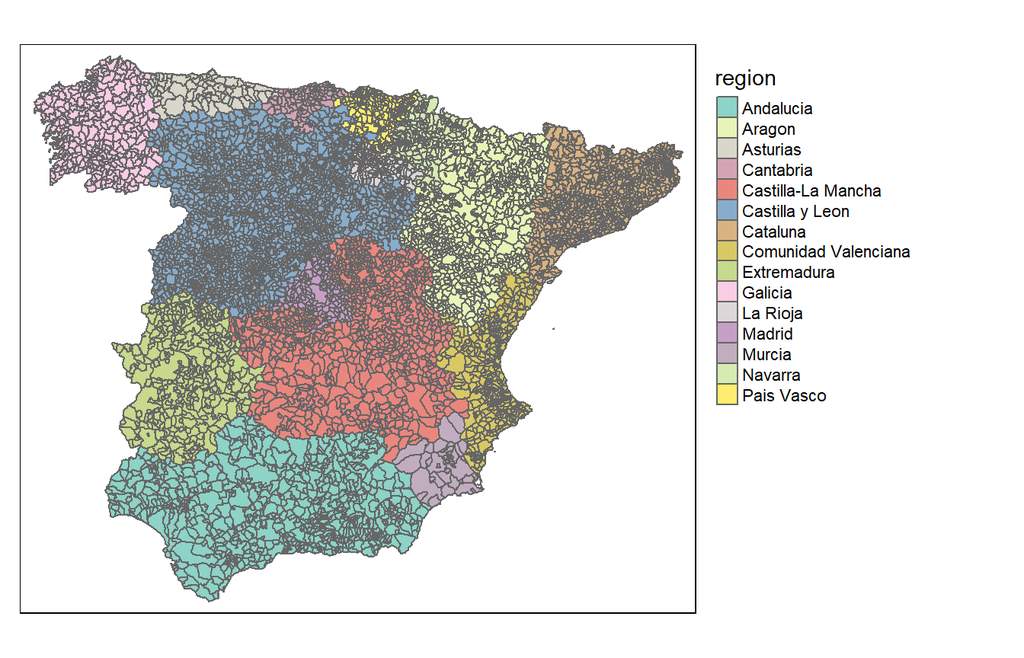

Figure 2: Disjoint partition for the Spanish municipalities based on the $D=15$ autonomous regions.

The neighbourhood order to add polygons at the border of the spatial subdomains is controlled by the `k` argument.

```r
## disjoint partition ##
carto.k0 <- divide_carto(carto=Carto_SpainMUN, ID.group="region", k=0)

## 1st order partition ##
carto.k1 <- divide_carto(carto=Carto_SpainMUN, ID.group="region", k=1)

## 2nd order partition ##
carto.k2 <- divide_carto(carto=Carto_SpainMUN, ID.group="region", k=2)
```

where the output of the `divide_carto()` function is a list of `sf` objects of length $D$ with the spatial polygons for each subdomain.

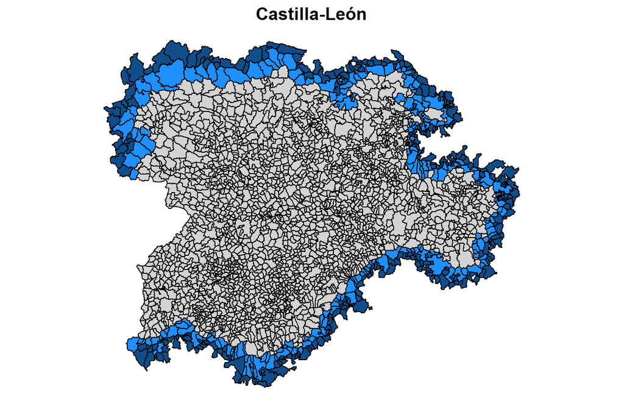

Figure 3: Spatial polygons for the autonomous region of Castilla y León with 1st and 2nd order neighbours in the border.

## `mergeINLA` function

This function takes local models fitted for each subregion of the whole spatial domain and unifies them into a single `inla` object. It is called by the main function `CAR_INLA()`, and is valid for both *Disjoint* and *k-order neighbourhood* models. In addition, approximations to model selection criteria such as the deviance information criterion (DIC) (Spiegelhalter et al., 2002) and Watanabe-Akaike information criterion (WAIC) (Watanabe, 2010) are also computed. See Orozco et al. (2020) for details on how to compute these measures for the scalable model proposals that are available in the **bigDM** package.

- **Computation of the overall log-risk $\alpha$**

  If the *Disjoint model* is fitted, the final log-risk surface is just the union of the posterior estimates of each submodel. However, a single estimate of the overall log-risk $\alpha$ can be obtained (`compute.fixed=TRUE` argument) by extracting samples from the joint posterior distribution of the linear predictors using the `inla.posterior.sample()` function of the **INLA** package. After joining the $S$ samples (default to 1000) from each submodel, we define

  $$\begin{equation*}
  \alpha^s=\frac{1}{n}\sum_{i=1}^n \log r_i, \quad \mbox{for} \quad s=1,\ldots,S
  \end{equation*}$$
  and then compute the kernel density estimate of $\alpha$.
- **Computation of the mixture distribution of $r_i$**

  If the *k-order neighbourhood model* is fitted, note that the final risk surface $\textbf{r} = (r_1,\ldots,r_n)^{'}$ is no longer the union of the posterior estimates obtained from each submodel. To obtain a unique posterior distribution of $r_i$ for each areal unit $i$, a mixture distribution of the estimated posterior probability density functions is computed using the conditional predictive ordinates (CPO) to compute the mixture weights. See Orozco et al. (2020) for full details about how these mixture distributions are computed.

In what follows, we show how to use the `mergeINLA()` function to reproduce the results obtained with the main `CAR_INLA()` function using the previously saved models for each spatial subdomain. The corresponding .Rdata objects have been renamed as `INLAsubmodels_Disjoint.Rdata`, `INLAsubmodels_order1.Rdata` and `INLAsubmodels_order2.Rdata`.

```r
## Disjoint model ##
load("temp/INLAsubmodels_Disjoint.Rdata")

Disjoint <- mergeINLA(inla.models=inla.models, k=0, seed=1234, n.sample=1000,
                      compute.fixed=TRUE, compute.DIC=TRUE)

summary(Disjoint)
```

```
#>
#> Call:
#>    c("inla(formula = formula, family = \"poisson\", data = data.INLA[[i]],
#>    ", " E = E, control.compute = list(dic = TRUE, cpo = TRUE, waic = TRUE,
#>    ", " config = TRUE), control.predictor = list(compute = TRUE, ", " cdf
#>    = c(log(1))), control.inla = list(strategy = strategy))" )
#> Time used:
#>     Pre = 4.08, Running = 84.4, Post = 5.71, Merging = 133
#> Fixed effects:
#>             mean    sd 0.025quant 0.5quant 0.975quant mode
#> (Intercept) 0.09 0.006      0.079     0.09      0.102 0.09
#>
#> Random effects:
#>   Name     Model
#>     ID.area Generic1 model
#>
#> Deviance Information Criterion (DIC) ...............: 28205.68
#> Deviance Information Criterion (DIC, saturated) ....: 8362.16
#> Effective number of parameters .....................: 297.87
#>
#> Watanabe-Akaike information criterion (WAIC) ...: 28182.07
#> Effective number of parameters .................: 251.22
#>
#> Posterior marginals for the linear predictor and
#>  the fitted values are computed
```

```r
## 1st order neighbourhood model ##
load("temp/INLAsubmodels_order1.Rdata")

order1 <- mergeINLA(inla.models=inla.models, k=1, seed=1234, n.sample=1000,
                      compute.fixed=FALSE, compute.DIC=TRUE)

summary(order1)
```

```
#>
#> Call:
#>    c("inla(formula = formula, family = \"poisson\", data = data.INLA[[i]],
#>    ", " E = E, control.compute = list(dic = TRUE, cpo = TRUE, waic = TRUE,
#>    ", " config = TRUE), control.predictor = list(compute = TRUE, ", " cdf
#>    = c(log(1))), control.inla = list(strategy = strategy))" )
#> Time used:
#>     Pre = 3.99, Running = 83.6, Post = 4.03, Merging = 117
#> Deviance Information Criterion (DIC) ...............: 28169.86
#> Deviance Information Criterion (DIC, saturated) ....: 8326.33
#> Effective number of parameters .....................: 290.04
#>
#> Watanabe-Akaike information criterion (WAIC) ...: 28142.65
#> Effective number of parameters .................: 240.46
```

```r
## 2nd order neighbourhood model ##
load("temp/INLAsubmodels_order2.Rdata")

order2 <- mergeINLA(inla.models=inla.models, k=2, seed=1234, n.sample=1000,
                      compute.fixed=FALSE, compute.DIC=TRUE)

summary(order2)
```

```
#>
#> Call:
#>    c("inla(formula = formula, family = \"poisson\", data = data.INLA[[i]],
#>    ", " E = E, control.compute = list(dic = TRUE, cpo = TRUE, waic = TRUE,
#>    ", " config = TRUE), control.predictor = list(compute = TRUE, ", " cdf
#>    = c(log(1))), control.inla = list(strategy = strategy))" )
#> Time used:
#>     Pre = 3.84, Running = 99, Post = 3.93, Merging = 217
#> Deviance Information Criterion (DIC) ...............: 28153.12
#> Deviance Information Criterion (DIC, saturated) ....: 8309.59
#> Effective number of parameters .....................: 298.56
#>
#> Watanabe-Akaike information criterion (WAIC) ...: 28120.56
#> Effective number of parameters .................: 242.59
```

## References

Besag, J., York, J., & Mollié, A. (1991). Bayesian image restoration, with two applications in spatial statistics. *Annals of the Institute of Statistical Mathematics*, *43*(1), 1–20. https://doi.org/10.1007/bf00116466

Dean, C., Ugarte, M., & Militino, A. (2001). Detecting interaction between random region and fixed age effects in disease mapping. *Biometrics*, *57*(1), 197–202. https://doi.org/10.1111/j.0006-341x.2001.00197.x

Goicoa, T., Adin, A., Ugarte, M. D., & Hodges, J. S. (2018). In spatio-temporal disease mapping models, identifiability constraints affect PQL and INLA results. *Stochastic Environmental Research and Risk Assessment*, *32*(3), 749–770. https://doi.org/10.1007/s00477-017-1405-0

Leroux, B. G., Lei, X., & Breslow, N. (1999). Estimation of disease rates in small areas: A new mixed model for spatial dependence. In M. Halloran & D. Berry (Eds.), *Statistical models in epidemiology, the environment, and clinical trials* (pp. 179–191). Springer-Verlag: New York.

Orozco-Acosta, E., Adin, A., & Ugarte, M. D. (2020). Scalable Bayesian modeling for smoothing disease mapping risks in large spatial datasets. *arXiv Preprint*. https://arxiv.org/abs/2007.07724

Riebler, A., Sørbye, S. H., Simpson, D., & Rue, H. (2016). An intuitive bayesian spatial model for disease mapping that accounts for scaling. *Statistical Methods in Medical Research*, *25*(4), 1145–1165.

Rue, H., Martino, S., & Chopin, N. (2009). Approximate Bayesian inference for latent Gaussian models by using integrated nested Laplace approximations. *Journal of the Royal Statistical Society: Series B (Statistical Methodology)*, *71*(2), 319–392. https://doi.org/10.1111/j.1467-9868.2008.00700.x

Simpson, D., Rue, H., Riebler, A., Martins, T. G., Sørbye, S. H., & others. (2017). Penalising model component complexity: A principled, practical approach to constructing priors. *Statistical Science*, *32*(1), 1–28.

Spiegelhalter, D. J., Best, N. G., Carlin, B. P., & Van Der Linde, A. (2002). Bayesian measures of model complexity and fit. *Journal of the Royal Statistical Society: Series B (Statistical Methodology)*, *64*(4), 583–639. https://doi.org/10.1111/1467-9868.00353

Sørbye, S. H., & Rue, H. (2014). Scaling intrinsic gaussian markov random field priors in spatial modelling. *Spatial Statistics*, *8*, 39–51.

Ugarte, M. D., Adin, A., & Goicoa, T. (2016). Two-level spatially structured models in spatio-temporal disease mapping. *Statistical Methods in Medical Research*, *25*(4), 1080–1100. https://doi.org/doi.org/10.1177/0962280216660423

Watanabe, S. (2010). Asymptotic equivalence of Bayes cross validation and widely applicable information criterion in singular learning theory. *Journal of Machine Learning Research*, *11*(Dec), 3571–3594.